# Part I - (Flights and performance)

### 8. Cancellations vs delays (weather, security, NAS

This section explores the data to determine whether there is any correlation between cancellation and weather, security and NAS delays

```python
numeric_vars =['CANCELLED','SECURITY_DELAY', 'WEATHER_DELAY', 'NAS_DELAY', 'ARR_DELAY', 'DEP_DELAY']
```

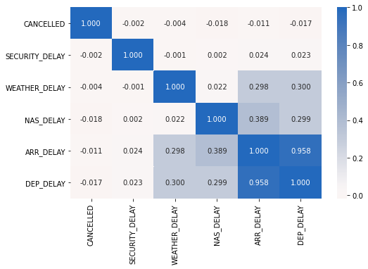

```python
# correlation plot
plt.figure(figsize = [8, 5])
sb.heatmap(df_flights_12_2019_new[numeric_vars].corr(), annot = True, fmt = '.3f',
           cmap = 'vlag_r', center = 0)
plt.show()
```

**The following is some additional plotting done to further explore the data to see if there are any correlations.**

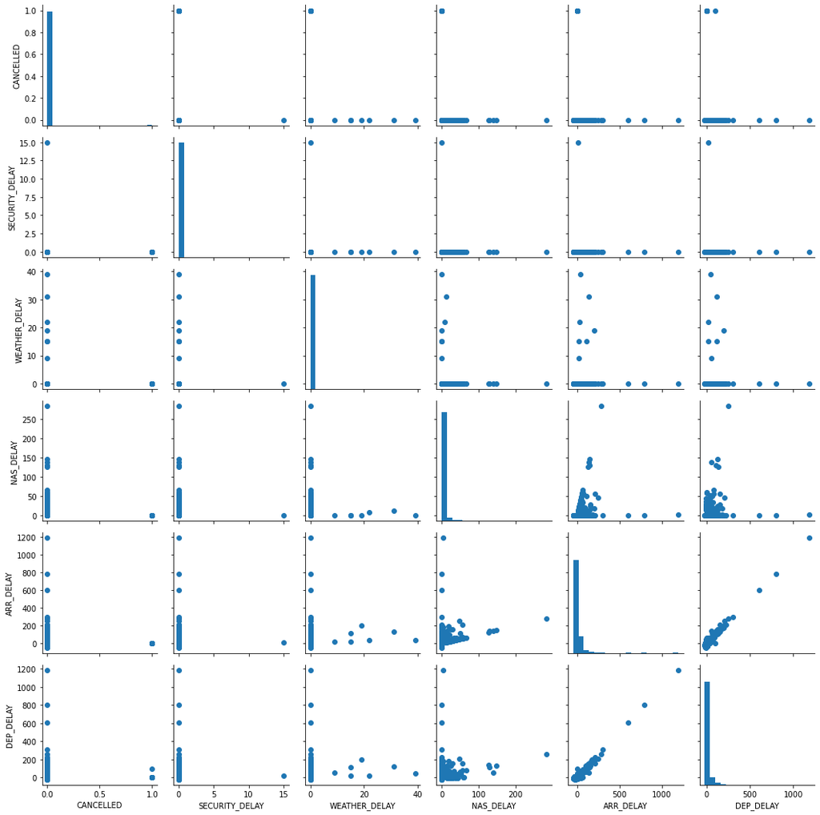

```python
#Create sample data
samples = np.random.choice(df_flights_12_2019_new.shape[0], 1000, replace = False)
samp_12_2019 = df_flights_12_2019_new.loc[samples,:]
g = sb.PairGrid(data = samp_12_2019, vars = numeric_vars)
g = g.map_diag(plt.hist, bins = 20);
g.map_offdiag(plt.scatter)
```

## Multivariate Exploration

In this part of the analysis I want to explore how the different delay categories and the cancellations impacted the ten busiest airports (origin airports with most flights)

### 1. Activities at top ten busiest airports

This section will explore the top 10 busiest airports (where flights originated) and produce a visual of the type of cancellations and volume of each cancellation type - 'Carrier', 'Weather', 'National Air System' and 'Security' impacting the airports.

```python
#Top ten airports with the most flights in December 2019
top_airports_2019 = df_flights_12_2019_new['ORIGIN_CITY'].value_counts().head(10).index
top_airports_2019
```

```
Index(['(ATL) Atlanta, GA', '(ORD) Chicago, IL', '(DFW) Dallas/Fort Worth, TX',
       '(DEN) Denver, CO', '(CLT) Charlotte, NC', '(LAX) Los Angeles, CA',
       '(PHX) Phoenix, AZ', '(IAH) Houston, TX', '(SFO) San Francisco, CA',
       '(LGA) New York, NY'],
      dtype='object')
```

```python
# #Top ten airports with the most flights in December 2020
top_airports_2020 = df_flights_12_2020_new['ORIGIN_CITY'].value_counts().head(10).index
top_airports_2020
```

```
Index(['(ATL) Atlanta, GA', '(DFW) Dallas/Fort Worth, TX', '(DEN) Denver, CO',
       '(CLT) Charlotte, NC', '(ORD) Chicago, IL', '(PHX) Phoenix, AZ',
       '(LAX) Los Angeles, CA', '(DTW) Detroit, MI', '(MSP) Minneapolis, MN',
       '(SLC) Salt Lake City, UT'],
      dtype='object')
```

```python
#Select the records from the 2019 dataframe only for the cities with the top ten airports (in top_airports_2019)
top_ten_airports_2019 = df_flights_12_2019_new[df_flights_12_2019_new['ORIGIN_CITY'].isin(top_airports_2019)]
```

```python
#Select the records from the 2020 dataframe only for the cities with the top ten airports (in top_airports_2019)
top_ten_airports_2020 = df_flights_12_2020_new[df_flights_12_2020_new['ORIGIN_CITY'].isin(top_airports_2020)]
top_ten_airports_2020
```

|  | YEAR | QUARTER | MONTH | DAY_OF_MONTH | DAY_OF_WEEK | FL_DATE | OP_UNIQUE_CARRIER | OP_CARRIER_AIRLINE_ID | OP_CARRIER | TAIL_NUM | ... | DIV2_AIRPORT_SEQ_ID | DIV2_WHEELS_ON | DIV2_TOTAL_GTIME | DIV2_LONGEST_GTIME | DIV2_WHEELS_OFF | DIV2_TAIL_NUM | CARRIER_DESCRIPTION | CANCELLED_DESCRIPTION | ORIGIN_CITY | DEST_CITY |
| --- | --- | --- | --- | --- | --- | --- | --- | --- | --- | --- | --- | --- | --- | --- | --- | --- | --- | --- | --- | --- | --- |
| 4 | 2020 | 4 | 12 | 1 | 2 | 12/1/2020 | AA | 19805 | AA | N914UY | ... |  |  |  |  |  | 0 | American Airlines Inc. | NaN | (CLT) Charlotte, NC | (MCO) Orlando, FL |
| 5 | 2020 | 4 | 12 | 3 | 4 | 12/3/2020 | AA | 19805 | AA | N587UW | ... |  |  |  |  |  | 0 | American Airlines Inc. | NaN | (CLT) Charlotte, NC | (MCO) Orlando, FL |
| 6 | 2020 | 4 | 12 | 4 | 5 | 12/4/2020 | AA | 19805 | AA | N583UW | ... |  |  |  |  |  | 0 | American Airlines Inc. | NaN | (CLT) Charlotte, NC | (MCO) Orlando, FL |
| 7 | 2020 | 4 | 12 | 6 | 7 | 12/6/2020 | AA | 19805 | AA | N150UW | ... |  |  |  |  |  | 0 | American Airlines Inc. | NaN | (CLT) Charlotte, NC | (MCO) Orlando, FL |
| 8 | 2020 | 4 | 12 | 7 | 1 | 12/7/2020 | AA | 19805 | AA | N586UW | ... |  |  |  |  |  | 0 | American Airlines Inc. | NaN | (CLT) Charlotte, NC | (MCO) Orlando, FL |
| ... | ... | ... | ... | ... | ... | ... | ... | ... | ... | ... | ... | ... | ... | ... | ... | ... | ... | ... | ... | ... | ... |
| 370925 | 2020 | 4 | 12 | 23 | 3 | 12/23/2020 | WN | 19393 | WN | N281WN | ... |  |  |  |  |  | 0 | Southwest Airlines Co. | NaN | (LAX) Los Angeles, CA | (SMF) Sacramento, CA |
| 370926 | 2020 | 4 | 12 | 23 | 3 | 12/23/2020 | WN | 19393 | WN | N284WN | ... |  |  |  |  |  | 0 | Southwest Airlines Co. | NaN | (LAX) Los Angeles, CA | (SMF) Sacramento, CA |
| 370927 | 2020 | 4 | 12 | 23 | 3 | 12/23/2020 | WN | 19393 | WN | N8552Z | ... |  |  |  |  |  | 0 | Southwest Airlines Co. | NaN | (LAX) Los Angeles, CA | (STL) St. Louis, MO |
| 370928 | 2020 | 4 | 12 | 23 | 3 | 12/23/2020 | WN | 19393 | WN | N431WN | ... |  |  |  |  |  | 0 | Southwest Airlines Co. | NaN | (LAX) Los Angeles, CA | (STL) St. Louis, MO |
| 370929 | 2020 | 4 | 12 | 23 | 3 | 12/23/2020 | WN | 19393 | WN | N8512U | ... |  |  |  |  |  | 0 | Southwest Airlines Co. | NaN | (LAX) Los Angeles, CA | (TUS) Tucson, AZ |

134532 rows × 89 columns

The following code gets the data and presents a visualization of the cancellation rates at the top 10 airports identified above, for the four cancellation types - Carrier, Weather, National Air System and Security

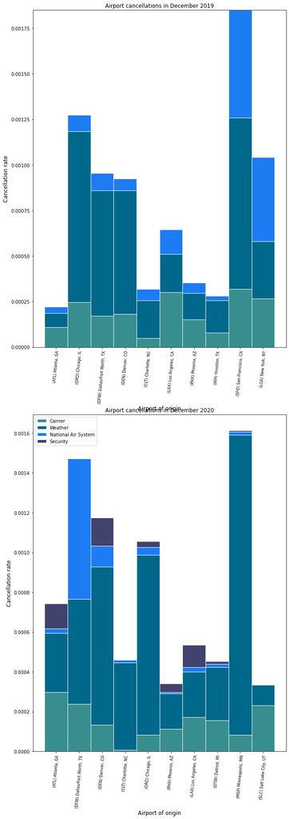

```python
cancelled_type =['Carrier', 'Weather', 'National Air System', 'Security']
#Set a variable 'i' to indicate which array the calculated cancellation rate should be added to, for the bar plots
#A maximum of 4 bars will be stacked - one for each cancellation type
i = 1
#define variables to store cancellation rates for 2019 and 2020
bars1_2019, bars2_2019, bars3_2019, bars4_2019, bars1_2020, bars2_2020, bars3_2020, bars4_2020  = [], [], [], [], [], [], [], []

#Follow the steps in the order indicated to understand the flow of the code
#########################################  STEP 3  ###################################################
# function (cancellation_type)
# Input parameters:    airport, cancellation type
# Output:   Calculated rate of cancellation type
# Description:
#  This function calculates the rate of cancellation types for each airport and passes it back to call_cancel_type,
#   which appends it to an array to be plotted later
#############################################################################################################################
def cancellation_type(airport, cancel_type, t_year):
#use 'shape' to get the number of occurrences of the cancellation code for airport
    if (t_year == '2019'):
        code_occurence_2019 = top_ten_airports_2019[(top_ten_airports_2019['ORIGIN_CITY'] == airport) &
                                                    (top_ten_airports_2019['CANCELLED_DESCRIPTION'] == cancel_type)].shape[0]
        # calculate the rate of the cancellation code
       # print("code_cancel in 2019",code_occurence_2019 )
        return (code_occurence_2019/top_ten_airports_2019.shape[0])

    elif (t_year == '2020'):
        code_occurence_2020 = top_ten_airports_2020[(top_ten_airports_2020['ORIGIN_CITY'] == airport) &
                                                    (top_ten_airports_2020['CANCELLED_DESCRIPTION'] == cancel_type)].shape[0]
        # calculate the rate of the cancellation code
        #print("code_cancel in 2020",code_occurence_2020 )
        return (code_occurence_2020/top_ten_airports_2020.shape[0])


#########################################  STEP 2  ###################################################
# function (call_cancel_type)
# Input parameters:    Cancellation type
# Output: Gets calculated rate of cancellation type returned by function 'cancellation_type' and appends to bars1, bars2, bars3,
#           bars4 arrays
# Description:
#           This function calls function cancellation_type to get the cancellation type rate, by doing the following:
#            1. for each of the top 10 airports, it passes the cancellation type and a top ten airport to the cancellation_type
#               function above
#            2. takes the cancellation type rate returned from cancellation_type and appends it to the corresponding bar array
#               to be plotted later
#############################################################################################################################
def call_cancel_type(cancel_type, i, t_year):
    #print("tyear in call_cancel_type function is", t_year)
    if t_year == '2019':
        for airport in top_airports_2019:
            if i == 1:
                bars1_2019.append(cancellation_type(airport, cancel_type, t_year))
            if i == 2:
                bars2_2019.append(cancellation_type(airport, cancel_type, t_year))
            if i == 3:
                bars3_2019.append(cancellation_type(airport, cancel_type, t_year))
            if i == 4:
                bars4_2019.append(cancellation_type(airport, cancel_type, t_year))
    elif t_year == '2020':
        for airport2 in top_airports_2020:
            if i == 1:
 #               print("airport in 2020", airport2)
                bars1_2020.append(cancellation_type(airport2, cancel_type, t_year))
            if i == 2:
                bars2_2020.append(cancellation_type(airport2, cancel_type, t_year))
            if i == 3:
                bars3_2020.append(cancellation_type(airport2, cancel_type, t_year))
            if i == 4:
                bars4_2020.append(cancellation_type(airport2, cancel_type, t_year))

            #print("i in 2020", i)

#########################################  STEP 1  #########################################################################
# Description:
#       There are two for loops below - the outer will iterate over the values in array 'top_year' twice, and the inner
#       will iterate over the array (cancelled_type) of cancellation types and calls the function 'call_cancel_type' for each
#       cancellation type and passes a cancellation type,as well as a counter variable 'i', which does not increase beyond
#       the number of cancellation types
#############################################################################################################################
top_year = ['2019', '2020']

for t_year in top_year:
    for cancel_type in cancelled_type:
        #Call function in step 2
        call_cancel_type(cancel_type, i, t_year  )
        i = i+1
    #Reset i after each year
    i = 1
##--------- Stack the first two bars - bars1 + bars2
bars12_2019 = np.add(bars1_2019, bars2_2019).tolist()

##--------- Stack the 3rd bar on top of the first two bars
bars123_2019 = np.add(bars12_2019, bars3_2019).tolist()

##--------- The position of the bars on the x-axis
r1 = [0,1,2,3,4,5,6,7,8,9]
r2 = [0,1,2,3,4,5,6,7,8,9]

# Names of group and bar width
names_2019 = list(top_airports_2019)
barWidth = 1

########################################  Plot the graphs #####################################
f,ax=plt.subplots(nrows=2,figsize=(10,30))

#Create bars with colors
ax[0].bar(r1, bars1_2019, color='#388E8E', edgecolor='white', width=barWidth, tick_label=names_2019)
ax[0].bar(r1, bars2_2019, bottom=bars1_2019, color='#00688B', edgecolor='white', width=barWidth)
ax[0].bar(r1, bars3_2019, bottom=bars12_2019, color='#1D7CF2', edgecolor='white', width=barWidth)
ax[0].bar(r1, bars4_2019, bottom=bars123_2019, color='#42426F', edgecolor='white', width=barWidth)

ax[0].tick_params("x", labelrotation=85, labelsize='small')

ax[0].set_xlabel('Airport of origin', fontsize=12)
ax[0].set_ylabel('Cancellation rate', fontsize=12)
ax[0].set_title('Airport cancellations in December 2019')

plt.legend(cancelled_type)

###### 2020 plot

##--------- Stack the first two bars - bars1 + bars2
bars12_2020 = np.add(bars1_2020, bars2_2020).tolist()
#             print("BARS12 is", bars12)

##--------- Stack the 3rd bar on top of the first two bars
bars123_2020 = np.add(bars12_2020, bars3_2020).tolist()

##--------- The position of the bars on the x-axis
# r = [0,1,2,3,4,5,6,7,8,9]

# Names of group and bar width
names_2020 = list(top_airports_2020)
barWidth = 1

#Create bars with colors provided
ax[1].bar(r2, bars1_2020, color='#388E8E', edgecolor='white', width=barWidth,  tick_label=names_2020)
ax[1].bar(r2, bars2_2020, bottom=bars1_2020, color='#00688B', edgecolor='white', width=barWidth)
ax[1].bar(r2, bars3_2020, bottom=bars12_2020, color='#1D7CF2', edgecolor='white', width=barWidth)
ax[1].bar(r2, bars4_2020, bottom=bars123_2020, color='#42426F', edgecolor='white', width=barWidth)

ax[1].tick_params("x", labelrotation=85, labelsize='small')

ax[1].set_xlabel('Airport of origin', fontsize=12)
ax[1].set_ylabel('Cancellation rate', fontsize=12)
ax[1].set_title('Airport cancellations in December 2020')

plt.legend(cancelled_type)


plt.show()
```

**Observation for December 2019:** Most of the cancellations were weather related, with Chicago and San Francisco having the highest rate. Whereas National Air System (NAS) cancellations were the least in most airports, except for San Francisco and New York La Guardia, which had significantly higher NAS delays. No security delays occured in the top ten airports where flights originated, and carrier related delays were the second lowest across. Overall, San Francisco airport had the largest combined cancellations, with Chicago following behind.

**Observation for December 2020:** Most of the cancellations were weather related, with Minneapolis (MSP) airport having the highest number of weather related delays, followed by Chicago (ORD) and Denver airports. Unlike in December 2019, there were some security related cancellations in 7 out of the 10 airports plotted, with Denver, Atlanta (ATL) and Los Angeles (LAX) amongst the highest. All of the airports experienced carrier related delays, with Charlotte (CLT) having the least impact. Of the four cancellation types, Dallas Forst Worth appears to have had a great share of the three of them, i.e. Carrier, Weather, and NAS.